# Which are the characteristics of the songs I like?

The aim of this work is to explore, visualize, analyze with the hope of producing significant results that could encounter the interest of the reader and satisfy its maker. Analyzing **the features** of a Spotify playlist with the intent of finding patterns or any statistic significance in them in order to explain the criterion (or the criteria) beneath which a song is liked or not (by me, let’s say).

## Preliminary Operations

Loading useful libraries, setting working directory and reading data from `.csv` file

This is the structure of the dataset

```
## 'data.frame':    2017 obs. of  17 variables:
##  $ X               : int  0 1 2 3 4 5 6 7 8 9 ...
##  $ acousticness    : num  0.0102 0.199 0.0344 0.604 0.18 0.00479 0.0145 0.0202 0.0481 0.00208 ...
##  $ danceability    : num  0.833 0.743 0.838 0.494 0.678 0.804 0.739 0.266 0.603 0.836 ...
##  $ duration_ms     : int  204600 326933 185707 199413 392893 251333 241400 349667 202853 226840 ...
##  $ energy          : num  0.434 0.359 0.412 0.338 0.561 0.56 0.472 0.348 0.944 0.603 ...
##  $ instrumentalness: num  2.19e-02 6.11e-03 2.34e-04 5.10e-01 5.12e-01 0.00 7.27e-06 6.64e-01 0.00 0.00 ...
##  $ key             : int  2 1 2 5 5 8 1 10 11 7 ...
##  $ liveness        : num  0.165 0.137 0.159 0.0922 0.439 0.164 0.207 0.16 0.342 0.571 ...
##  $ loudness        : num  -8.79 -10.4 -7.15 -15.24 -11.65 ...
##  $ mode            : int  1 1 1 1 0 1 1 0 0 1 ...
##  $ speechiness     : num  0.431 0.0794 0.289 0.0261 0.0694 0.185 0.156 0.0371 0.347 0.237 ...
##  $ tempo           : num  150.1 160.1 75 86.5 174 ...
##  $ time_signature  : num  4 4 4 4 4 4 4 4 4 4 ...
##  $ valence         : num  0.286 0.588 0.173 0.23 0.904 0.264 0.308 0.393 0.398 0.386 ...
##  $ target          : int  1 1 1 1 1 1 1 1 1 1 ...
##  $ song_title      : Factor w/ 1956 levels "'Till I Collapse",..: 1053 1346 1917 1054 1254 1486 319 667 783 409 ...
##  $ artist          : Factor w/ 1343 levels "!!!","*NSYNC",..: 455 221 455 97 636 360 360 877 313 521 ...
```

```
##   X acousticness danceability duration_ms energy instrumentalness key liveness
## 1 0      0.01020        0.833      204600  0.434         0.021900   2   0.1650
## 2 1      0.19900        0.743      326933  0.359         0.006110   1   0.1370
## 3 2      0.03440        0.838      185707  0.412         0.000234   2   0.1590
## 4 3      0.60400        0.494      199413  0.338         0.510000   5   0.0922
## 5 4      0.18000        0.678      392893  0.561         0.512000   5   0.4390
## 6 5      0.00479        0.804      251333  0.560         0.000000   8   0.1640
##   loudness mode speechiness   tempo time_signature valence target
## 1   -8.795    1      0.4310 150.062              4   0.286      1
## 2  -10.401    1      0.0794 160.083              4   0.588      1
## 3   -7.148    1      0.2890  75.044              4   0.173      1
## 4  -15.236    1      0.0261  86.468              4   0.230      1
## 5  -11.648    0      0.0694 174.004              4   0.904      1
## 6   -6.682    1      0.1850  85.023              4   0.264      1
##       song_title           artist
## 1       Mask Off           Future
## 2        Redbone Childish Gambino
## 3   Xanny Family           Future
## 4 Master Of None      Beach House
## 5 Parallel Lines      Junior Boys
## 6     Sneakinâ\200\231            Drake
```

We notice that the first column is a little bit strange, it looks like a replication of the index columns shifted of -1 value (this could be due to a small grammatical error in the dataset or some error in the reading process); to avoid that we could either modify the dataset.csv file (not the best choice since it was taken from external sources), troubleshoot the read function (slow and painful) or mutate it into a new data frame we would use from now on (everything is traced inside the script, this sounds like the best choice).

This data frame contains pieces of information about music features, all the variables are provided by Spotify itself who then allows us to exploit these great datasets.

We could find some interesting patterns between the variables and we hope to predict something about their success. A similar work could be found on [this link](https://www.kaggle.com/cihanoklap/top-songs-on-spotify-what-makes-them-popular) and a great study is found at [this link](https://essay.utwente.nl/75422/1/NIJKAMP_BA_IBA.pdf)

But first of all we want to check the quality of our data, looking for *n/a* values

```
## [1] 0
```

Aparently we have encountered a good dataset without missing values, in case we would have found them we could have decided to remove them or, if the were quite a lot, deal with other techniques such as average replacing or regression.

Since we want to understand the ratio behind music features and success we can look for strongly dependent variables and select one of them, or chose a combination in order to reduce cardinality and computational complexity without losing variance.

Duration range:

```
## [1]  0.2673667 16.7437833
```

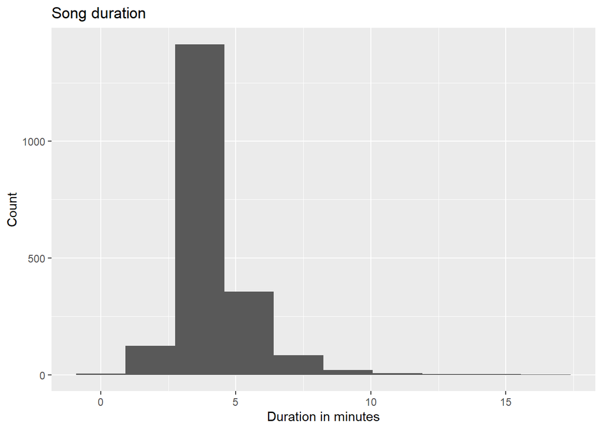

We can now apply this new feature to give more insight to the next graphs.

```
##
##   long medium  short
##    505   1440     72
```

## Spider Charts

In order to compare music features of songs I like and don’t I wanted to use a Spider Graph, in the following you can have an insight of which feature I appreciate the most.

[interactive chart not shown]

As we can see, there are no disrupting differences in the two graphs, but since every variable is compressed between 0 and 1, also minor changes could be significant. For example: *acoustics* is slightly higher in song that I didn’t like while *instrumental ness* is slightly higher in the song I liked and so does *danceability*. Instead *valence* is harder to interpret since it’s an overall score of the song, in this case it could mean that I like song with a higher overall score made by Spotify itself, which is ok.

## Fitting the glm model

After having the data separated we’re fitting a `glm()` model:

```
##
## Call:
## glm(formula = target ~ ., family = binomial, data = train)
##
## Deviance Residuals:
##     Min       1Q   Median       3Q      Max
## -2.1760  -1.0437   0.3938   1.0402   2.3179
##
## Coefficients: (1 not defined because of singularities)
##                    Estimate Std. Error z value Pr(>|z|)
## (Intercept)      -2.235e+00  1.188e+00  -1.881 0.059934 .
## acousticness     -1.608e+00  3.116e-01  -5.160 2.47e-07 ***
## danceability      1.948e+00  4.319e-01   4.512 6.44e-06 ***
## duration_ms       2.604e-06  1.317e-06   1.977 0.048079 *
## energy            4.490e-01  5.097e-01   0.881 0.378342
## instrumentalness  1.144e+00  2.487e-01   4.600 4.22e-06 ***
## key               9.338e-03  1.549e-02   0.603 0.546622
## liveness          8.904e-02  3.766e-01   0.236 0.813086
## loudness         -1.010e-01  2.756e-02  -3.665 0.000247 ***
## mode             -4.962e-02  1.165e-01  -0.426 0.670028
## speechiness       3.786e+00  7.051e-01   5.369 7.93e-08 ***
## tempo             3.601e-03  2.205e-03   1.633 0.102427
## time_signature   -3.733e-01  2.418e-01  -1.544 0.122650
## valence           8.646e-01  2.770e-01   3.121 0.001803 **
## duration_minutes         NA         NA      NA       NA
## lenghtmedium     -3.546e-01  2.001e-01  -1.772 0.076402 .
## lenghtshort       1.049e+00  4.268e-01   2.458 0.013980 *
## ---
## Signif. codes:  0 '***' 0.001 '**' 0.01 '*' 0.05 '.' 0.1 ' ' 1
##
## (Dispersion parameter for binomial family taken to be 1)
##
##     Null deviance: 2095.8  on 1511  degrees of freedom
## Residual deviance: 1864.6  on 1496  degrees of freedom
## AIC: 1896.6
##
## Number of Fisher Scoring iterations: 4
```

```
##
## Call:
## glm(formula = target ~ acousticness + danceability + instrumentalness +
##     loudness + speechiness + valence + lenght, family = binomial,
##     data = train)
##
## Deviance Residuals:
##     Min       1Q   Median       3Q      Max
## -2.2261  -1.0431   0.4135   1.0418   2.1718
##
## Coefficients:
##                  Estimate Std. Error z value Pr(>|z|)
## (Intercept)      -1.83378    0.29950  -6.123 9.19e-10 ***
## acousticness     -1.71717    0.28410  -6.044 1.50e-09 ***
## danceability      1.64340    0.40082   4.100 4.13e-05 ***
## instrumentalness  1.28529    0.23778   5.405 6.47e-08 ***
## loudness         -0.08707    0.02053  -4.242 2.22e-05 ***
## speechiness       3.88792    0.68938   5.640 1.70e-08 ***
## valence           0.95292    0.26065   3.656 0.000256 ***
## lenghtmedium     -0.64456    0.13783  -4.676 2.92e-06 ***
## lenghtshort       0.50221    0.33052   1.519 0.128647
## ---
## Signif. codes:  0 '***' 0.001 '**' 0.01 '*' 0.05 '.' 0.1 ' ' 1
##
## (Dispersion parameter for binomial family taken to be 1)
##
##     Null deviance: 2095.8  on 1511  degrees of freedom
## Residual deviance: 1875.5  on 1503  degrees of freedom
## AIC: 1893.5
##
## Number of Fisher Scoring iterations: 4
```

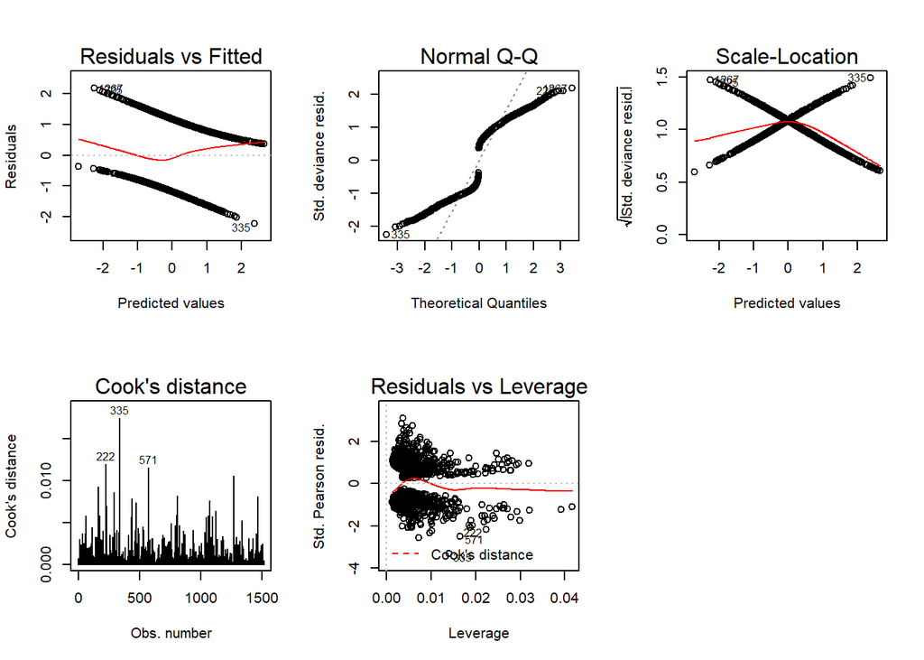

The graphs show what looks like a good classification model, with residuals clearly distributed on two lines, no normality, but it’s normal since the residuals and the model is supposed to be **binomial**, and few outliears that don’t look like to be influential observation as we can see from the **Residuals vs LEverage** graph.

The prediciotn made by fitting this model can be summarized in the following table:

```
##
## FALSE  TRUE
##   158   347
```

Looking at GoF parameters it looks like a good fit since the ratio between Residual Deviance and DoF it’s close to 1. We can use this model to make a prediction and the next step would be training an ML algorithm to predict the results and compare them.